# Командный проект. Этап 4

Рост дендритов

Андрюшин Н.С., Комягин А.Н., Жибицкая Е.Д., Лисовская А.В., Мосолов А.Д., Колонтырский И.Р.

2026-05-16

# Информация о выполняющих

## Команда. Часть 1

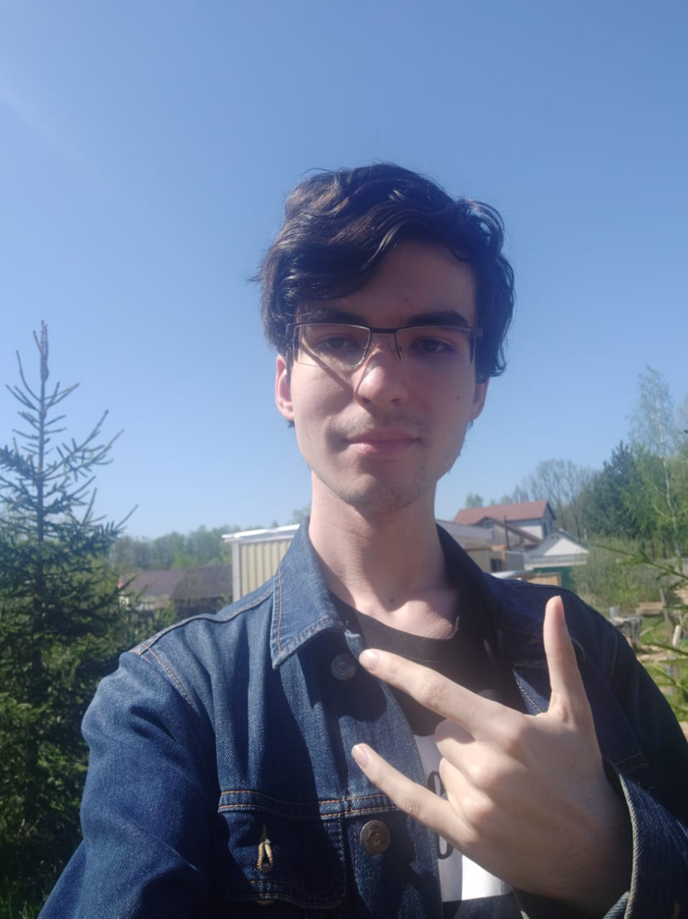

**Андрюшин Никита Сергеевич**

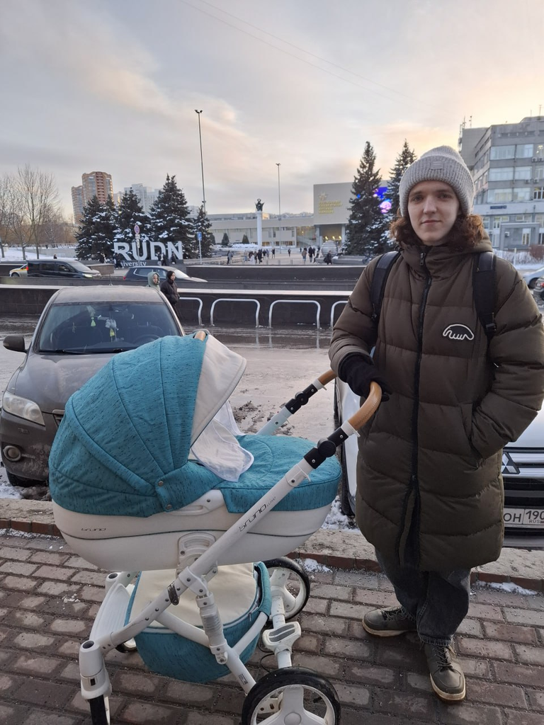

**Комягин Андрей Николаевич**

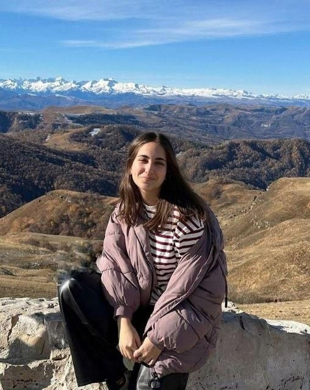

**Жибицкая Евгения Дмитриевна**

## Команда. Часть 2

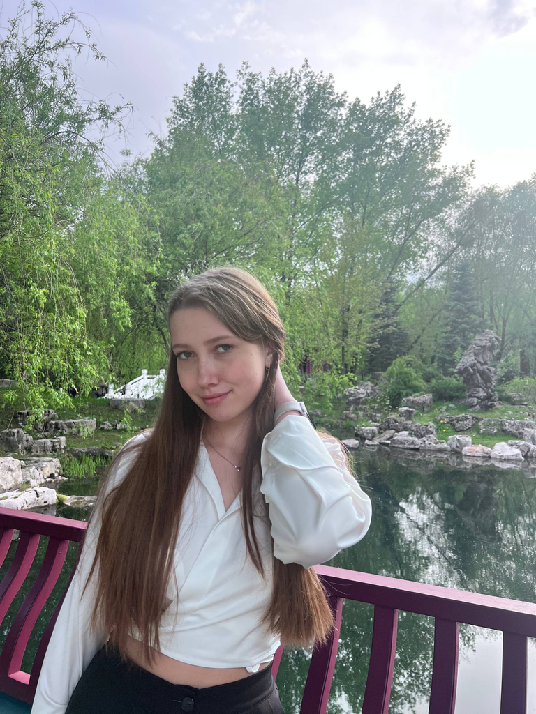

**Лисовская Арина Валерьевна**

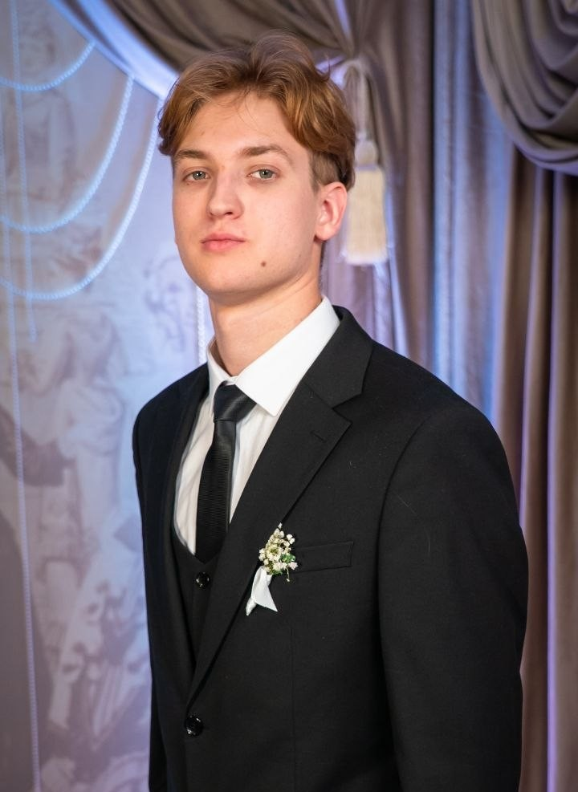

**Мосолов Александр Денисович**

[figure not shown]

**Колонтырский Илья Русланович**

## Введение: что такое дендриты и зачем их моделировать?

**Дендриты** — древовидные кристаллические структуры, возникающие при затвердевании переохлажденных расплавов.  
**Практическая значимость:** В металлургии (литье, сварка, 3D-печать металлами) дендритная микроструктура напрямую определяет прочность, пластичность и качество детали.  
**Цель проекта:** Создать с нуля оптимизированную компьютерную модель, воспроизводящую формирование дендритов на основе фундаментальных законов физики.

## Физическая постановка задачи

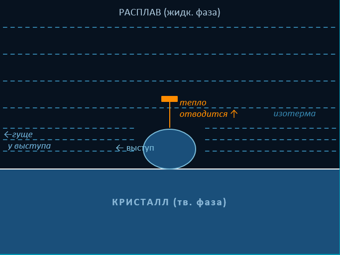

Формирование дендрита — это результат конкуренции двух термодинамических механизмов:

**Неустойчивость Муллинса–Секерки (Движущая сила)**:  
Случайный выступ на фронте кристаллизации попадает в область с высоким градиентом температур. Тепло отводится быстрее - выступ растет с ускорением.

**Эффект Гиббса–Томсона (Стабилизация)**:  
Поверхностное натяжение сглаживает кристалл. Чем острее выступ (выше кривизна), тем ниже локальная температура плавления, что тормозит бесконечное ветвление.

## Алгоритмическая модель: от непрерывности к сетке

**Дискретное пространство:** Двумерная сетка (клеточный автомат). Ячейки: 0 (расплав), 1 (кристалл).  
**Разделение времени:** Физически диффузия тепла происходит на порядки быстрее роста кристалла.  
1 Макро-шаг = Фазовый переход.

m Микро-шагов = Диффузия тепла (решение уравнения теплопроводности).

**Устойчивость:** Вычисление числа m микро-шагов происходит динамически по критерию Куранта–Фридрихса–Леви (CFL).

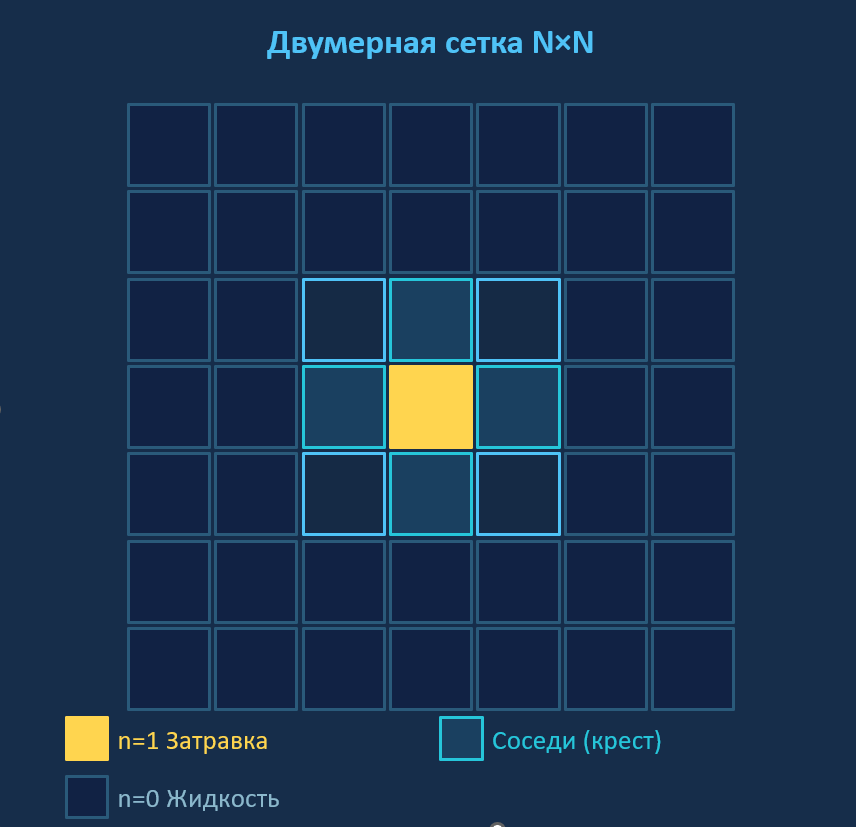

## Программная реализация и архитектура

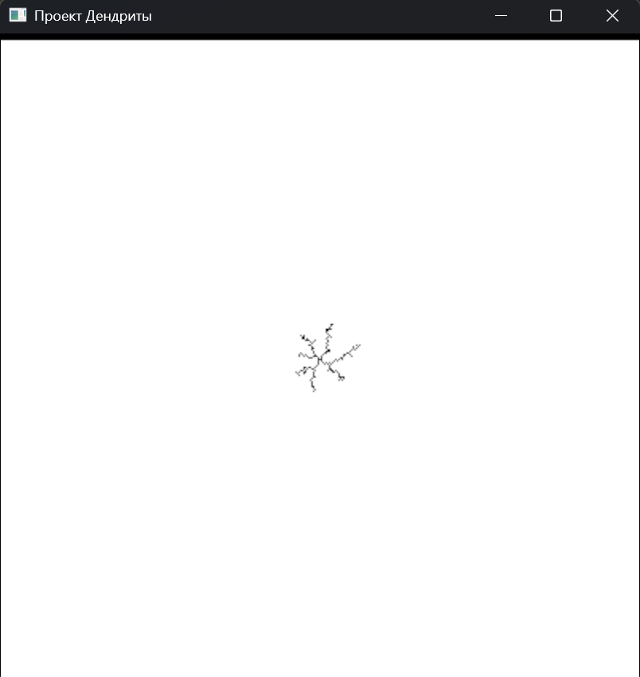

**Язык программирования:** Модель реализована на **Rust.**  
**Производительность:** Строгая типизация и сборка –release позволили ускорить расчеты сетки 401 × 401 в 10-20 раз по сравнению с отладочным режимом.  
**Оптимизация:** Алгоритм фазового перехода обходит не всю матрицу, а только динамическую коллекцию HashSet (множество ячеек активного фронта).  
**Визуализация:** Собственный графический модуль для рендера фазового поля в реальном времени.

## Преодоление артефактов сеточной модели

Во время разработки мы столкнулись с характерными проблемами, которые были успешно решены физическими методами:

**Проблема “Квадратного роста” - Решение: Анизотропия.**

Изотропная сетка не дает ветвления. Введение 4-кратной анизотропии поверхностной энергии запустило выделение главных осей.

**Проблема “Черной рамки” - Решение: Условие Неймана.**

Заморозка краев происходила из-за постоянного охлаждения границ (условие Дирихле). Мы перешли к теплоизолированным границам

## Вычислительные эксперименты: Никель (Ni)

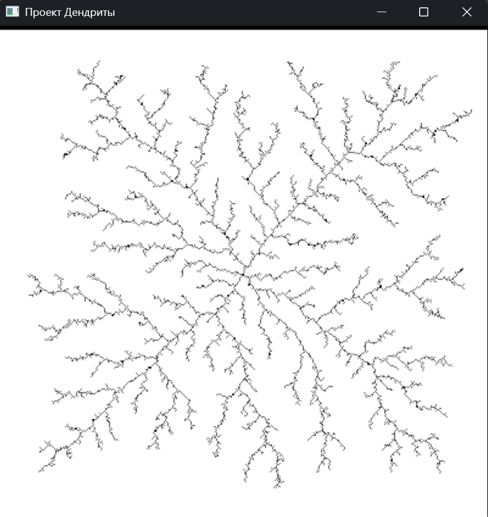

## Вычислительные эксперименты: Алюминий (Al)

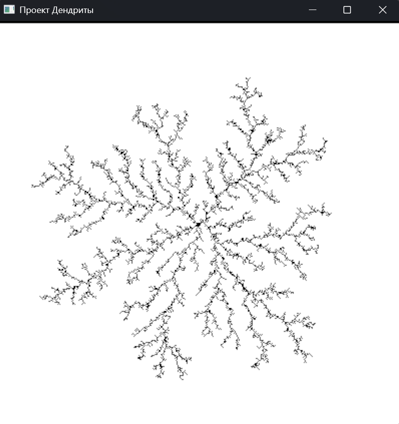

## Вычислительные эксперименты: Медь (Cu)

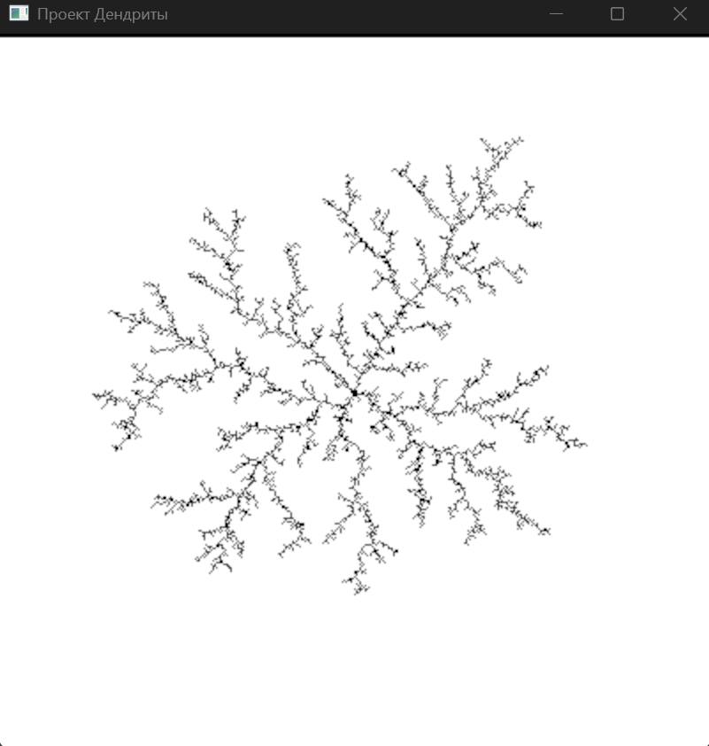

## Заключение и итоги

**Успешный переход от теории к практике:**  
Модель стабильно воспроизводит сложные процессы структурно-фазовой самоорганизации.

**Техническое совершенство:**  
Код на Rust оптимизирован, артефакты конечно-разностной схемы (вычислительный взрыв, влияние границ, изотропность) физически обоснованно устранены.

**Научная достоверность:** Чувствительность модели к реальным свойствам металлов доказана серией экспериментов. Различные режимы роста (Ni, Al, Cu) соответствуют физической теории.

Разработанный комплекс — готовая база для дальнейших исследований в вычислительном материаловедении.

**Репозиторий и материалы:** [dendron-npi23.github.io](https://dendron-npi23.github.io/)